# Project: Bay Wheels Data Visualization

## Overview

In this project, we aimed to analyze the dataset from Bay Wheels to understand or at least find some insights about the consumer behaviour in the bay area. The Bay Wheels shares all the data from each ride in their website (you can find it here: https://www.lyft.com/bikes/bay-wheels/system-data ), for this project we are going to focus on the data in 2019.

In order to achieve our goal, this analysis will be guided by the following points:

- Distribution of trips in terms of month, day of week and hour
- Most common and least common start station
- Distribution of trip duration
- Distribution of trip distance
- Relationship between trip duration and distance
- User Habit/Behavior

#### Rental Access Method

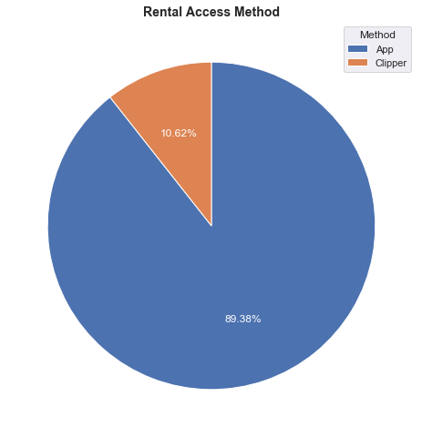

```python
rental = df_clean.rental_access_method.value_counts()
rental

# Pie to show distribution
plt.figure(figsize=[14.70, 8.27])
plt.pie(rental, labels = rental.index, startangle = 90, autopct= '%1.2f%%', counterclock = False, textprops={'color':'white'});
plt.legend(['App', 'Clipper'], #rental.index
           title='Method',
           loc='upper right')
plt.title('Rental Access Method', fontsize=14,  fontweight='bold');
```

> Almost 90% of Bay Wheels users tend to user app to rent a bike. Since the app is preferred, we can enhance the app feature to bring better user experience.

#### Bay Wheels Montly Usage by User Type

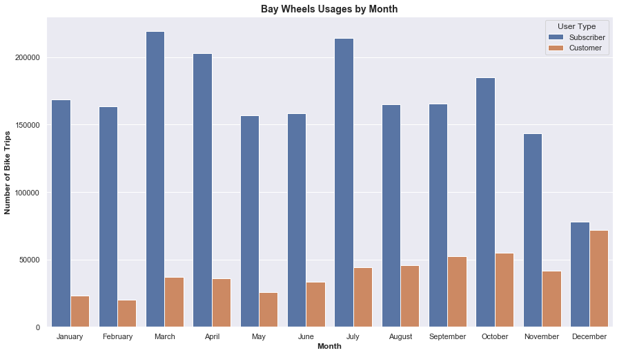

```python
# Monthly usage of the Bay Wheels by each user type
plt.figure(figsize=[14.70, 8.27])
ax = sns.countplot(data = df_clean,
                   x = 'start_time_month',
                   hue='user_type')
ax.set_title('Bay Wheels Usages by Month', fontdict = {'fontsize':14,  'fontweight':'bold'})
ax.set_xlabel('Month', fontsize = 12, weight = "bold")
ax.set_ylabel('Number of Bike Trips', fontsize = 12, weight = "bold")
#ax.set(xlabel='Month', ylabel='Number of Bike Trips', title='Bay Wheels Usage by Month')
ax.set_xticklabels(ax.get_xticklabels(), rotation=0)
ax.legend(title='User Type');
```

> In overall, Subscribers always have a relatively high usages of Bay Wheels service compared to customers in almost every month except December which difference is not significant.

#### Distribution of Bike Trip Duration by User Type

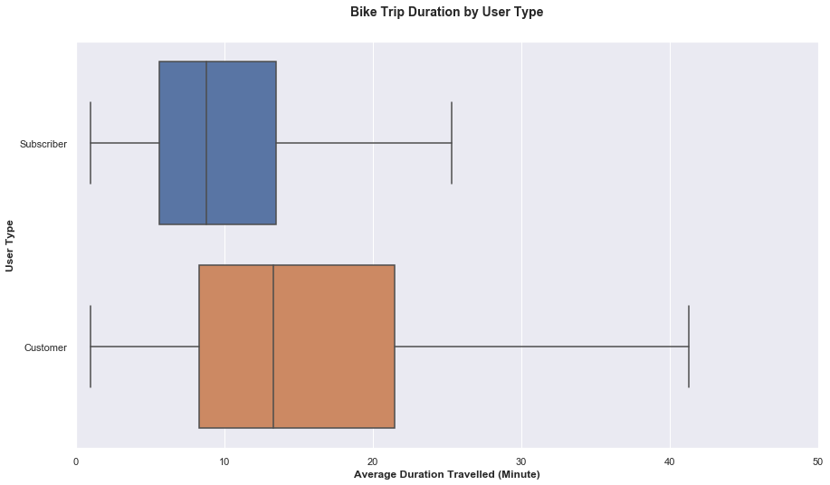

```python
# Distribution of duration
plt.figure(figsize=[14.70, 8.27])
sns.boxplot(data = df_clean,
            y = 'user_type',
            x = 'duration_min',
            showfliers = False);
plt.title('Bike Trip Duration by User Type', y=1.05, fontsize=14, fontweight='bold')
plt.ylabel('User Type', fontsize = 12, weight = "bold")
plt.xlabel('Average Duration Travelled (Minute)', fontsize = 12, weight = "bold")
plt.xlim(0, 50);
```

> This figure shows that customers will use the bike longer compared to subsriber. We can assume most of the subscribers use the bike for a short travel, for work or study while customers is tends to enjoy the bike trip.

#### Bike Usage by Hour by Day of Week

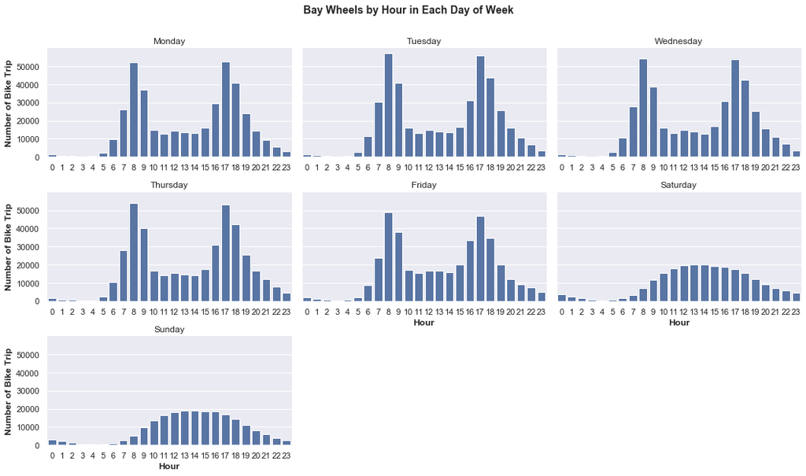

```python
day_order = ['Monday', 'Tuesday', 'Wednesday', 'Thursday', 'Friday', 'Saturday', 'Sunday']
dayClasses = pd.api.types.CategoricalDtype(ordered = True, categories = day_order)
df_clean['start_time_weekday'] = df_clean['start_time_weekday'].astype(dayClasses)

g = sns.FacetGrid(data = df_clean, col = 'start_time_weekday', col_wrap = 3, height = 8.27/3,  aspect = (14.70/3)/(8.27/3), sharex = False)
g.map(sns.countplot, 'start_time_hour',  color = base_color)
g.set_titles('{col_name}')
g.set_xlabels('Hour', fontsize = 12, weight = "bold");
g.set_ylabels('Number of Bike Trip', fontsize = 12, weight = "bold");
g.fig.suptitle('Bay Wheels by Hour in Each Day of Week', y=1.05, fontsize=14, fontweight='bold');
```

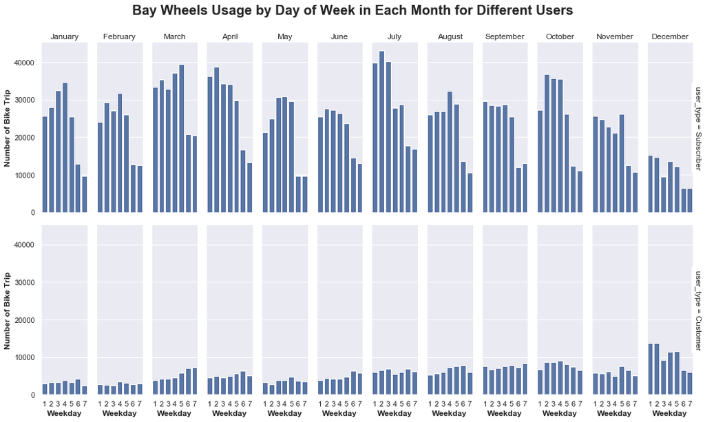

```python
day_order = ['Monday', 'Tuesday', 'Wednesday', 'Thursday', 'Friday', 'Saturday', 'Sunday']
g = sns.FacetGrid(data = df_clean, col = 'start_time_month', row = 'user_type', height = 8.27/2,  aspect = (14.70/12)/(8.27/2),
                  margin_titles = True)
g.map(sns.countplot, 'start_time_weekday',  color = base_color, order = day_order)
g.set_titles(row_template = '', col_template = '{col_name}')
g.set_xlabels('Weekday', fontsize = 12, weight = "bold");
g.set_ylabels('Number of Bike Trip', fontsize = 12, weight = "bold");
g.fig.suptitle('Bay Wheels Usage by Day of Week in Each Month for Different Users', y=1.05, fontsize=20, fontweight='bold')
g.set(xticklabels=['1', '2', '3', '4', '5', '6', '7'])
plt.tight_layout();
```

> From the visualization above, we can see the difference of usage by day of week is not significant in Customers. We can conclude again most of the Subcribers take the bike to work and study so the weekdays usage is always higher while well distributed shape found in frequency of bike usage in Customer suggest that they are using Bay Wheels service for different purposes